# Divvy-trip-2019 & 2020: A Comparative Analysis of Rider Behavior

Data Analyst

2025-08-06

# **Project Overview**

The “Divvy-trip-2019 & 2020” project is an analysis of Divvy bike-sharing data, focusing on the fourth quarter of 2019 and the first quarter of 2020. The primary objective is to compare ride-sharing habits between two key user types: **members** (subscribers) and **casual riders**. The analysis is conducted using the R programming language, with a strong reliance on packages from the **tidyverse** ecosystem, including `dplyr` for data manipulation and `ggplot2` for data visualization. This report details the methodology and key findings from the analysis.

# **Data and Methodology**

### **Data Loading and Initial Inspection**

The analysis begins by loading two separate CSV files: `Divvy_Trips_2019_Q4.csv` and `Divvy_Trips_2020_Q1.csv`. To ensure consistency for merging, several data cleaning steps were performed:

- The column names of the 2019 data were renamed to match the 2020 data’s naming convention (e.g., `ride_id`, `started_at`, `ended_at`).
- The `birthyear`, `gender`, and `tripduration` columns were removed from the 2019 data.
- The `start_lat`, `start_lng`, `end_lat`, and `end_lng` columns were removed from the 2020 data.

### **Data Cleaning and Transformation**

Once the datasets were standardized, they were combined into a single data frame called `all_trips` using `bind_rows()`. Further transformations included:

- The `member_casual` column was standardized by recoding “Subscriber” to “member” and “Customer” to “casual”.
- New columns—`date`, `month`, `day`, `year`, and `day_of_week`—were extracted from the timestamp columns to facilitate time-based analysis.
- A new column, `ride_length`, was created to capture the duration of each ride in seconds by calculating the time difference between `ended_at` and `started_at`.
- “Bad” data was filtered out, specifically rides with a duration less than 0 or those starting from the station “HQ QR”.

# **Key Findings and Analysis**

### **Descriptive Statistics on `ride_length`**

Initial descriptive statistics revealed significant differences in ride duration between the two rider types. The overall mean, median, minimum, and maximum ride lengths were calculated. A key finding was that **casual riders consistently have a longer average ride duration than members**.

### **Riding Behavior by Day of the Week**

The days of the week were reordered correctly to provide a clear, chronological view of riding patterns. The analysis then focused on comparing average ride times and the number of rides across different days for each user group.

**Visualizations and Insights:**

```r
library(tidyverse)
library(conflicted)
conflict_prefer("filter", "dplyr")
```

```
## [conflicted] Will prefer dplyr::filter over any other package.
```

```r
conflict_prefer("lag", "dplyr")
```

```
## [conflicted] Will prefer dplyr::lag over any other package.
```

```r
#=====================
# STEP 1: COLLECT DATA
#=====================
library(readr)
q1_2019 <- read_csv("C:/Users/Anees/Desktop/Divvy_Trip_2020/Divvy_Trips_2019_Q4.csv")
q1_2020 <- read_csv("C:/Users/Anees/Desktop/Divvy_Trip_2020/Divvy_Trips_2020_Q1.csv")
#====================================================
# STEP 2: WRANGLE DATA AND COMBINE INTO A SINGLE FILE
#====================================================
# Compare column names each of the files
# While the names don't have to be in the same order, they DO need to match perfectly before
#we can use a command to join them into one file
colnames(q1_2019)
```

```
##  [1] "trip_id"           "start_time"        "end_time"
##  [4] "bikeid"            "tripduration"      "from_station_id"
##  [7] "from_station_name" "to_station_id"     "to_station_name"
## [10] "usertype"          "gender"            "birthyear"
```

```r
colnames(q1_2020)
```

```
##  [1] "ride_id"            "rideable_type"      "started_at"
##  [4] "ended_at"           "start_station_name" "start_station_id"
##  [7] "end_station_name"   "end_station_id"     "start_lat"
## [10] "start_lng"          "end_lat"            "end_lng"
## [13] "member_casual"
```

```r
install.packages("dplyr")
# Load the dplyr package to use the rename() function
library(dplyr)
```

```r
names(q1_2019) <- c("ride_id", "started_at", "ended_at", "rideable_type", "tripduration",
                   "start_station_id", "start_station_name", "end_station_id",
                   "end_station_name", "member_casual", "gender", "birthyear")
```

```r
# Inspect the dataframes and look for incongruencies
str(q1_2019)
```

```
## spc_tbl_ [704,054 × 12] (S3: spec_tbl_df/tbl_df/tbl/data.frame)
##  $ ride_id           : num [1:704054] 25223640 25223641 25223642 25223643 25223644 ...
##  $ started_at        : POSIXct[1:704054], format: "2019-10-01 00:01:39" "2019-10-01 00:02:16" ...
##  $ ended_at          : POSIXct[1:704054], format: "2019-10-01 00:17:20" "2019-10-01 00:06:34" ...
##  $ rideable_type     : num [1:704054] 2215 6328 3003 3275 5294 ...
##  $ tripduration      : num [1:704054] 940 258 850 2350 1867 ...
##  $ start_station_id  : num [1:704054] 20 19 84 313 210 156 84 156 156 336 ...
##  $ start_station_name: chr [1:704054] "Sheffield Ave & Kingsbury St" "Throop (Loomis) St & Taylor St" "Milwaukee Ave & Grand Ave" "Lakeview Ave & Fullerton Pkwy" ...
##  $ end_station_id    : num [1:704054] 309 241 199 290 382 226 142 463 463 336 ...
##  $ end_station_name  : chr [1:704054] "Leavitt St & Armitage Ave" "Morgan St & Polk St" "Wabash Ave & Grand Ave" "Kedzie Ave & Palmer Ct" ...
##  $ member_casual     : chr [1:704054] "Subscriber" "Subscriber" "Subscriber" "Subscriber" ...
##  $ gender            : chr [1:704054] "Male" "Male" "Female" "Male" ...
##  $ birthyear         : num [1:704054] 1987 1998 1991 1990 1987 ...
##  - attr(*, "spec")=
##   .. cols(
##   ..   trip_id = col_double(),
##   ..   start_time = col_datetime(format = ""),
##   ..   end_time = col_datetime(format = ""),
##   ..   bikeid = col_double(),
##   ..   tripduration = col_number(),
##   ..   from_station_id = col_double(),
##   ..   from_station_name = col_character(),
##   ..   to_station_id = col_double(),
##   ..   to_station_name = col_character(),
##   ..   usertype = col_character(),
##   ..   gender = col_character(),
##   ..   birthyear = col_double()
##   .. )
##  - attr(*, "problems")=<externalptr>
```

```r
str(q1_2020)
```

```
## spc_tbl_ [426,887 × 13] (S3: spec_tbl_df/tbl_df/tbl/data.frame)
##  $ ride_id           : chr [1:426887] "EACB19130B0CDA4A" "8FED874C809DC021" "789F3C21E472CA96" "C9A388DAC6ABF313" ...
##  $ rideable_type     : chr [1:426887] "docked_bike" "docked_bike" "docked_bike" "docked_bike" ...
##  $ started_at        : POSIXct[1:426887], format: "2020-01-21 20:06:59" "2020-01-30 14:22:39" ...
##  $ ended_at          : POSIXct[1:426887], format: "2020-01-21 20:14:30" "2020-01-30 14:26:22" ...
##  $ start_station_name: chr [1:426887] "Western Ave & Leland Ave" "Clark St & Montrose Ave" "Broadway & Belmont Ave" "Clark St & Randolph St" ...
##  $ start_station_id  : num [1:426887] 239 234 296 51 66 212 96 96 212 38 ...
##  $ end_station_name  : chr [1:426887] "Clark St & Leland Ave" "Southport Ave & Irving Park Rd" "Wilton Ave & Belmont Ave" "Fairbanks Ct & Grand Ave" ...
##  $ end_station_id    : num [1:426887] 326 318 117 24 212 96 212 212 96 100 ...
##  $ start_lat         : num [1:426887] 42 42 41.9 41.9 41.9 ...
##  $ start_lng         : num [1:426887] -87.7 -87.7 -87.6 -87.6 -87.6 ...
##  $ end_lat           : num [1:426887] 42 42 41.9 41.9 41.9 ...
##  $ end_lng           : num [1:426887] -87.7 -87.7 -87.7 -87.6 -87.6 ...
##  $ member_casual     : chr [1:426887] "member" "member" "member" "member" ...
##  - attr(*, "spec")=
##   .. cols(
##   ..   ride_id = col_character(),
##   ..   rideable_type = col_character(),
##   ..   started_at = col_datetime(format = ""),
##   ..   ended_at = col_datetime(format = ""),
##   ..   start_station_name = col_character(),
##   ..   start_station_id = col_double(),
##   ..   end_station_name = col_character(),
##   ..   end_station_id = col_double(),
##   ..   start_lat = col_double(),
##   ..   start_lng = col_double(),
##   ..   end_lat = col_double(),
##   ..   end_lng = col_double(),
##   ..   member_casual = col_character()
##   .. )
##  - attr(*, "problems")=<externalptr>
```

```r
# Convert ride_id and rideable_type to character so that they can stack correctly
q1_2019 <-  mutate(q1_2019, ride_id = as.character(ride_id)
,rideable_type = as.character(rideable_type))
```

```r
# Stack individual quarter's data frames into one big data frame
all_trips <- bind_rows(q1_2019, q1_2020)
```

```r
colnames(q1_2019)
```

```
##  [1] "ride_id"            "started_at"         "ended_at"
##  [4] "rideable_type"      "tripduration"       "start_station_id"
##  [7] "start_station_name" "end_station_id"     "end_station_name"
## [10] "member_casual"      "gender"             "birthyear"
```

```r
q1_2019_cleaned <- q1_2019 %>%
  select(-c(birthyear, gender, tripduration))

q1_2020_cleaned <- q1_2020 %>%
  select(-c(start_lat, start_lng, end_lat, end_lng))
```

```r
all_trips <- bind_rows(q1_2019_cleaned, q1_2020_cleaned)
```

```r
# View all column names
names(all_trips)
```

```
## [1] "ride_id"            "started_at"         "ended_at"
## [4] "rideable_type"      "start_station_id"   "start_station_name"
## [7] "end_station_id"     "end_station_name"   "member_casual"
```

```r
# Get a quick overview of the data, including column names
dplyr::glimpse(all_trips)
```

```
## Rows: 1,130,941
## Columns: 9
## $ ride_id            <chr> "25223640", "25223641", "25223642", "25223643", "25…
## $ started_at         <dttm> 2019-10-01 00:01:39, 2019-10-01 00:02:16, 2019-10-…
## $ ended_at           <dttm> 2019-10-01 00:17:20, 2019-10-01 00:06:34, 2019-10-…
## $ rideable_type      <chr> "2215", "6328", "3003", "3275", "5294", "1891", "10…
## $ start_station_id   <dbl> 20, 19, 84, 313, 210, 156, 84, 156, 156, 336, 77, 1…
## $ start_station_name <chr> "Sheffield Ave & Kingsbury St", "Throop (Loomis) St…
## $ end_station_id     <dbl> 309, 241, 199, 290, 382, 226, 142, 463, 463, 336, 5…
## $ end_station_name   <chr> "Leavitt St & Armitage Ave", "Morgan St & Polk St",…
## $ member_casual      <chr> "Subscriber", "Subscriber", "Subscriber", "Subscrib…
```

```r
#======================================================
# STEP 3: CLEAN UP AND ADD DATA TO PREPARE FOR ANALYSIS
#======================================================
# Inspect the new table that has been created
colnames(all_trips)
```

```
## [1] "ride_id"            "started_at"         "ended_at"
## [4] "rideable_type"      "start_station_id"   "start_station_name"
## [7] "end_station_id"     "end_station_name"   "member_casual"
```

```r
nrow(all_trips)
```

```
## [1] 1130941
```

```r
dim(all_trips)
```

```
## [1] 1130941       9
```

```r
head(all_trips)
```

```
## # A tibble: 6 × 9
##   ride_id started_at          ended_at            rideable_type start_station_id
##   <chr>   <dttm>              <dttm>              <chr>                    <dbl>
## 1 252236… 2019-10-01 00:01:39 2019-10-01 00:17:20 2215                        20
## 2 252236… 2019-10-01 00:02:16 2019-10-01 00:06:34 6328                        19
## 3 252236… 2019-10-01 00:04:32 2019-10-01 00:18:43 3003                        84
## 4 252236… 2019-10-01 00:04:32 2019-10-01 00:43:43 3275                       313
## 5 252236… 2019-10-01 00:04:34 2019-10-01 00:35:42 5294                       210
## 6 252236… 2019-10-01 00:04:38 2019-10-01 00:10:51 1891                       156
## # ℹ 4 more variables: start_station_name <chr>, end_station_id <dbl>,
## #   end_station_name <chr>, member_casual <chr>
```

```r
str(all_trips)
```

```
## tibble [1,130,941 × 9] (S3: tbl_df/tbl/data.frame)
##  $ ride_id           : chr [1:1130941] "25223640" "25223641" "25223642" "25223643" ...
##  $ started_at        : POSIXct[1:1130941], format: "2019-10-01 00:01:39" "2019-10-01 00:02:16" ...
##  $ ended_at          : POSIXct[1:1130941], format: "2019-10-01 00:17:20" "2019-10-01 00:06:34" ...
##  $ rideable_type     : chr [1:1130941] "2215" "6328" "3003" "3275" ...
##  $ start_station_id  : num [1:1130941] 20 19 84 313 210 156 84 156 156 336 ...
##  $ start_station_name: chr [1:1130941] "Sheffield Ave & Kingsbury St" "Throop (Loomis) St & Taylor St" "Milwaukee Ave & Grand Ave" "Lakeview Ave & Fullerton Pkwy" ...
##  $ end_station_id    : num [1:1130941] 309 241 199 290 382 226 142 463 463 336 ...
##  $ end_station_name  : chr [1:1130941] "Leavitt St & Armitage Ave" "Morgan St & Polk St" "Wabash Ave & Grand Ave" "Kedzie Ave & Palmer Ct" ...
##  $ member_casual     : chr [1:1130941] "Subscriber" "Subscriber" "Subscriber" "Subscriber" ...
```

```r
summary(all_trips)
```

```
##    ride_id            started_at                     ended_at
##  Length:1130941     Min.   :2019-10-01 00:01:39   Min.   :2019-10-01 00:06:34
##  Class :character   1st Qu.:2019-10-22 07:43:06   1st Qu.:2019-10-22 07:55:12
##  Mode  :character   Median :2019-12-03 23:35:50   Median :2019-12-04 00:20:41
##                     Mean   :2019-12-13 04:03:06   Mean   :2019-12-13 04:23:47
##                     3rd Qu.:2020-02-01 08:29:15   3rd Qu.:2020-02-01 08:49:25
##                     Max.   :2020-03-31 23:51:34   Max.   :2020-05-19 20:10:34
##
##  rideable_type      start_station_id start_station_name end_station_id
##  Length:1130941     Min.   :  2.0    Length:1130941     Min.   :  2
##  Class :character   1st Qu.: 77.0    Class :character   1st Qu.: 77
##  Mode  :character   Median :174.0    Mode  :character   Median :174
##                     Mean   :206.2                       Mean   :206
##                     3rd Qu.:294.0                       3rd Qu.:294
##                     Max.   :675.0                       Max.   :675
##                                                         NA's   :1
##  end_station_name   member_casual
##  Length:1130941     Length:1130941
##  Class :character   Class :character
##  Mode  :character   Mode  :character
##
##
##
##
```

```r
# In the "member_casual" column, replace "Subscriber" with "member" and "Customer" with "casual"
table(all_trips$member_casual)
```

```
##
##     casual   Customer     member Subscriber
##      48480     106194     378407     597860
```

```r
all_trips <-  all_trips %>%
  mutate(member_casual = recode(member_casual
                                ,"Subscriber" = "member"
                                ,"Customer" = "casual"))
```

```r
# Check to make sure the proper number of observations were reassigned
table(all_trips$member_casual)
```

```
##
## casual member
## 154674 976267
```

```r
# Add columns that list the date, month, day, and year of each ride
all_trips$date <- as.Date(all_trips$started_at)
all_trips$month <- format(as.Date(all_trips$date), "%m")
all_trips$day <- format(as.Date(all_trips$date), "%d")
all_trips$year <- format(as.Date(all_trips$date), "%Y")
all_trips$day_of_week <- format(as.Date(all_trips$date), "%A")
```

```r
# Add a "ride_length" calculation to all_trips (in seconds)
all_trips$ride_length <- difftime(all_trips$ended_at,all_trips$started_at)
```

```r
# Inspect the structure of the columns
str(all_trips)
```

```
## tibble [1,130,941 × 15] (S3: tbl_df/tbl/data.frame)
##  $ ride_id           : chr [1:1130941] "25223640" "25223641" "25223642" "25223643" ...
##  $ started_at        : POSIXct[1:1130941], format: "2019-10-01 00:01:39" "2019-10-01 00:02:16" ...
##  $ ended_at          : POSIXct[1:1130941], format: "2019-10-01 00:17:20" "2019-10-01 00:06:34" ...
##  $ rideable_type     : chr [1:1130941] "2215" "6328" "3003" "3275" ...
##  $ start_station_id  : num [1:1130941] 20 19 84 313 210 156 84 156 156 336 ...
##  $ start_station_name: chr [1:1130941] "Sheffield Ave & Kingsbury St" "Throop (Loomis) St & Taylor St" "Milwaukee Ave & Grand Ave" "Lakeview Ave & Fullerton Pkwy" ...
##  $ end_station_id    : num [1:1130941] 309 241 199 290 382 226 142 463 463 336 ...
##  $ end_station_name  : chr [1:1130941] "Leavitt St & Armitage Ave" "Morgan St & Polk St" "Wabash Ave & Grand Ave" "Kedzie Ave & Palmer Ct" ...
##  $ member_casual     : chr [1:1130941] "member" "member" "member" "member" ...
##  $ date              : Date[1:1130941], format: "2019-10-01" "2019-10-01" ...
##  $ month             : chr [1:1130941] "10" "10" "10" "10" ...
##  $ day               : chr [1:1130941] "01" "01" "01" "01" ...
##  $ year              : chr [1:1130941] "2019" "2019" "2019" "2019" ...
##  $ day_of_week       : chr [1:1130941] "Tuesday" "Tuesday" "Tuesday" "Tuesday" ...
##  $ ride_length       : 'difftime' num [1:1130941] 941 258 851 2351 ...
##   ..- attr(*, "units")= chr "secs"
```

```r
# Convert "ride_length" from Factor to numeric
is.factor(all_trips$ride_length)
```

```
## [1] FALSE
```

```r
all_trips$ride_length <- as.numeric(as.character(all_trips$ride_length))
is.numeric(all_trips$ride_length)
```

```
## [1] TRUE
```

```r
# Remove "bad" data
all_trips_v2 <- all_trips[!(all_trips$start_station_name == "HQ QR" | all_trips$ride_length<0),]
```

```r
#=====================================
# STEP 4: CONDUCT DESCRIPTIVE ANALYSIS
#=====================================
# Descriptive analysis on ride_length (all figures in seconds)
mean(all_trips_v2$ride_length)
```

```
## [1] 1245.514
```

```r
median(all_trips_v2$ride_length)
```

```
## [1] 574
```

```r
max(all_trips_v2$ride_length)
```

```
## [1] 9387024
```

```r
min(all_trips_v2$ride_length)
```

```
## [1] 1
```

```r
summary(all_trips_v2$ride_length)
```

```
##    Min. 1st Qu.  Median    Mean 3rd Qu.    Max.
##       1     347     574    1246     984 9387024
```

```r
# Compare members and casual users
aggregate(all_trips_v2$ride_length ~ all_trips_v2$member_casual, FUN = mean)
```

```
##   all_trips_v2$member_casual all_trips_v2$ride_length
## 1                     casual                4425.1888
## 2                     member                 754.0262
```

```r
aggregate(all_trips_v2$ride_length ~ all_trips_v2$member_casual, FUN = median)
```

```
##   all_trips_v2$member_casual all_trips_v2$ride_length
## 1                     casual                     1314
## 2                     member                      523
```

```r
aggregate(all_trips_v2$ride_length ~ all_trips_v2$member_casual, FUN = max)
```

```
##   all_trips_v2$member_casual all_trips_v2$ride_length
## 1                     casual                  9387024
## 2                     member                  5627611
```

```r
aggregate(all_trips_v2$ride_length ~ all_trips_v2$member_casual, FUN = min)
```

```
##   all_trips_v2$member_casual all_trips_v2$ride_length
## 1                     casual                        2
## 2                     member                        1
```

```r
# See the average ride time by each day for members vs casual users
aggregate(all_trips_v2$ride_length ~ all_trips_v2$member_casual + all_trips_v2$day_of_week,
FUN = mean)
```

```
##    all_trips_v2$member_casual all_trips_v2$day_of_week all_trips_v2$ride_length
## 1                      casual                   Friday                4880.5070
## 2                      member                   Friday                 723.4151
## 3                      casual                   Monday                3387.8809
## 4                      member                   Monday                 733.7172
## 5                      casual                 Saturday                4270.0765
## 6                      member                 Saturday                 920.0550
## 7                      casual                   Sunday                4456.7825
## 8                      member                   Sunday                 847.5988
## 9                      casual                 Thursday                4791.8870
## 10                     member                 Thursday                 708.9436
## 11                     casual                  Tuesday                4591.5132
## 12                     member                  Tuesday                 747.8537
## 13                     casual                Wednesday                4647.2634
## 14                     member                Wednesday                 717.0983
```

```r
# Order the days of the week
all_trips_v2$day_of_week <- ordered(all_trips_v2$day_of_week, levels=c("Sunday", "Monday",
"Tuesday", "Wednesday", "Thursday", "Friday", "Saturday"))
```

```r
# Now, run the average ride time by each day for members vs casual users
aggregate(all_trips_v2$ride_length ~ all_trips_v2$member_casual + all_trips_v2$day_of_week,
FUN = mean)
```

```
##    all_trips_v2$member_casual all_trips_v2$day_of_week all_trips_v2$ride_length
## 1                      casual                   Sunday                4456.7825
## 2                      member                   Sunday                 847.5988
## 3                      casual                   Monday                3387.8809
## 4                      member                   Monday                 733.7172
## 5                      casual                  Tuesday                4591.5132
## 6                      member                  Tuesday                 747.8537
## 7                      casual                Wednesday                4647.2634
## 8                      member                Wednesday                 717.0983
## 9                      casual                 Thursday                4791.8870
## 10                     member                 Thursday                 708.9436
## 11                     casual                   Friday                4880.5070
## 12                     member                   Friday                 723.4151
## 13                     casual                 Saturday                4270.0765
## 14                     member                 Saturday                 920.0550
```

```r
# analyze ridership data by type and weekday
all_trips_v2 %>%
mutate(weekday = wday(started_at, label = TRUE)) %>%
group_by(member_casual, weekday) %>%
summarise(number_of_rides = n()
,average_duration = mean(ride_length)) %>%
arrange(member_casual, weekday)
```

```
## # A tibble: 14 × 4
## # Groups:   member_casual [2]
##    member_casual weekday number_of_rides average_duration
##    <chr>         <ord>             <int>            <dbl>
##  1 casual        Sun               40213            4457.
##  2 casual        Mon               16489            3388.
##  3 casual        Tue               16624            4592.
##  4 casual        Wed               15428            4647.
##  5 casual        Thu               16433            4792.
##  6 casual        Fri               17541            4881.
##  7 casual        Sat               28174            4270.
##  8 member        Sun               90048             848.
##  9 member        Mon              162346             734.
## 10 member        Tue              179475             748.
## 11 member        Wed              158589             717.
## 12 member        Thu              158211             709.
## 13 member        Fri              146556             723.
## 14 member        Sat               81034             920.
```

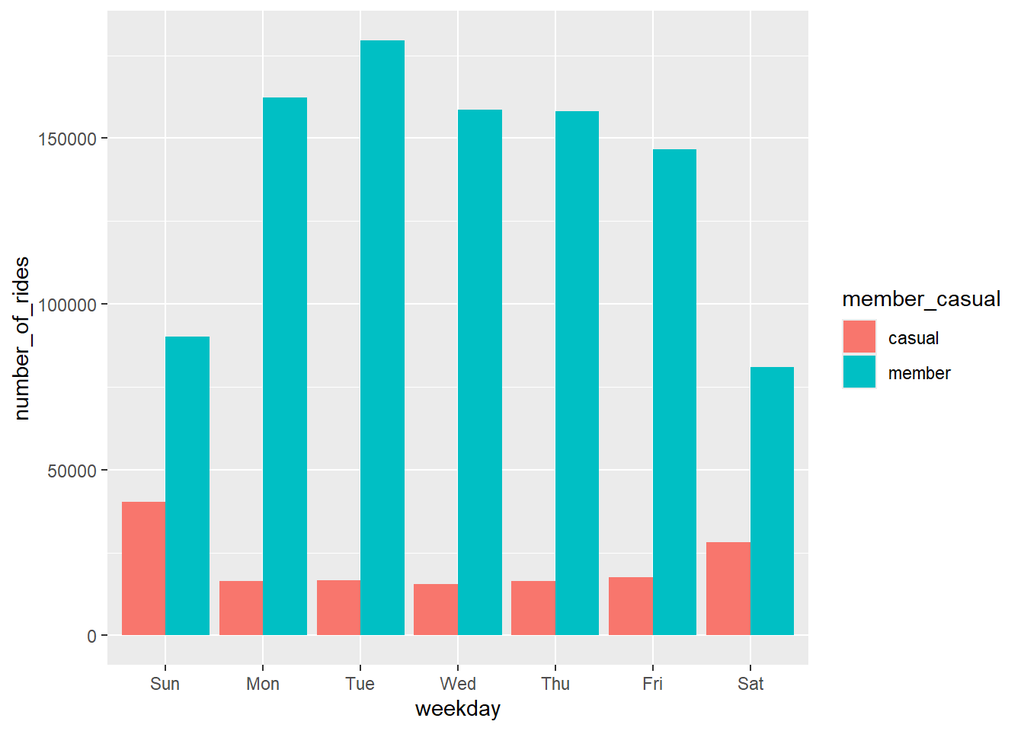

```r
# Let's visualize the number of rides by rider type
all_trips_v2 %>%
mutate(weekday = wday(started_at, label = TRUE)) %>%
group_by(member_casual, weekday) %>%
summarise(number_of_rides = n()
,average_duration = mean(ride_length)) %>%
arrange(member_casual, weekday)  %>%
ggplot(aes(x = weekday, y = number_of_rides, fill = member_casual)) +
geom_col(position = "dodge")
```

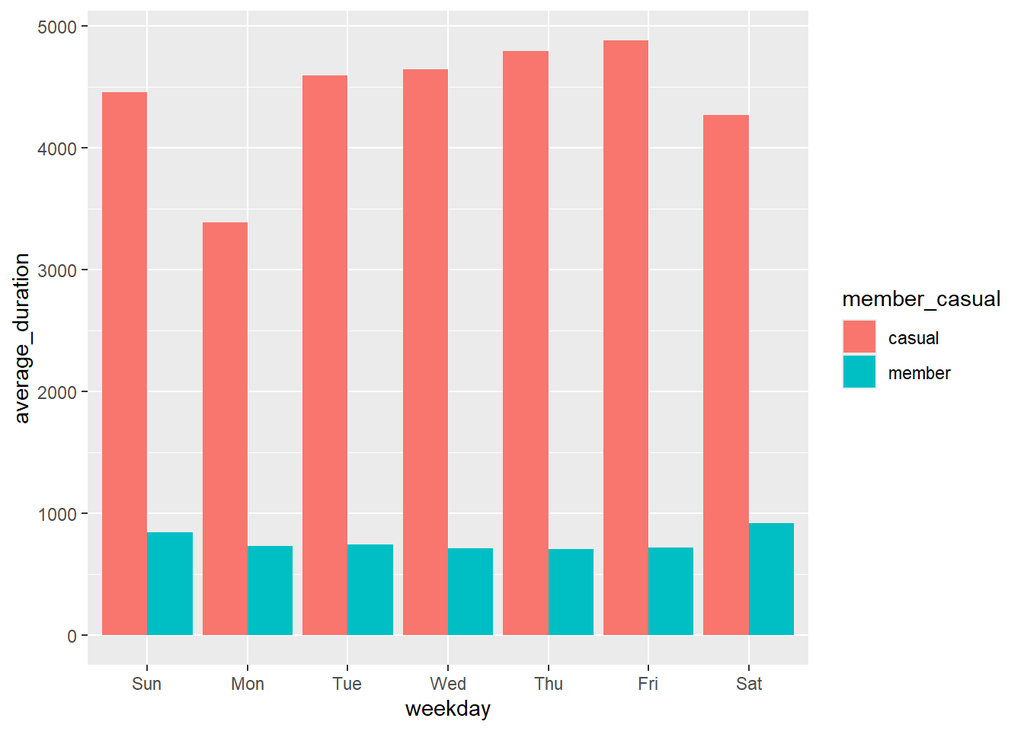

```r
# Let's create a visualization for average duration
all_trips_v2 %>%
mutate(weekday = wday(started_at, label = TRUE)) %>%
group_by(member_casual, weekday) %>%
summarise(number_of_rides = n()
,average_duration = mean(ride_length)) %>%
arrange(member_casual, weekday)  %>%
ggplot(aes(x = weekday, y = average_duration, fill = member_casual)) +
geom_col(position = "dodge")
```

```r
#=================================================
# STEP 5: EXPORT SUMMARY FILE FOR FURTHER ANALYSIS
#=================================================
counts <- aggregate(all_trips_v2$ride_length ~ all_trips_v2$member_casual +
all_trips_v2$day_of_week, FUN = mean)
write.csv(counts, file = 'avg_ride_length.csv')
```